# Diseños metodológicos y su aplicación en el campo

Santiago Benitez-Vieyra

# Distribución de Poisson

### Modelos para conteos

# Proceso Poisson

> Número de parejas, hijos, semillas, plántulas, granos de polen, etc. Número de individuos observados en un lapso de tiempo. Número de individuos observados en un área determinada.
- Registro de sucesos que ocurren en un lapso determinado de tiempo y que son independientes unos de otros.
- Aproximación a eventos de naturaleza binomial (de probabilidad muy pequeña) o a sucesos de naturaleza multinomial (categóricos).

# Distribución de Poisson

- Tiene un único parámetro, $\mu$ (suele aparecer como $\lambda$.
- La media es igual a la varianza.
- Al aumentar la media… aumenta la varianza.

La variable respuesta se distribuye como Poisson
$$Y_{i} \sim P(\mu_{i})$$
Su valor esperado es $\mu_{i}$, su varianza es igual a su valor esperado.
$$E(Y_{i}) = \mu_{i}$$
$$var(Y_{i} = \mu_{i})$$
El enlace canónico es logaritmo
$$\eta =log(\mu_{i})$$
Por lo que el valor esperado es igual al exponencial de la parte sistemática.
$$\mu_{i} = e^{\eta}$$
Colocando las variables predictoras en la parte sistemática…
$$\mu_{i} = e^{\beta_{0} + \beta_{1}X_{1i} + ... + \beta_{k}X_{ki}}$$

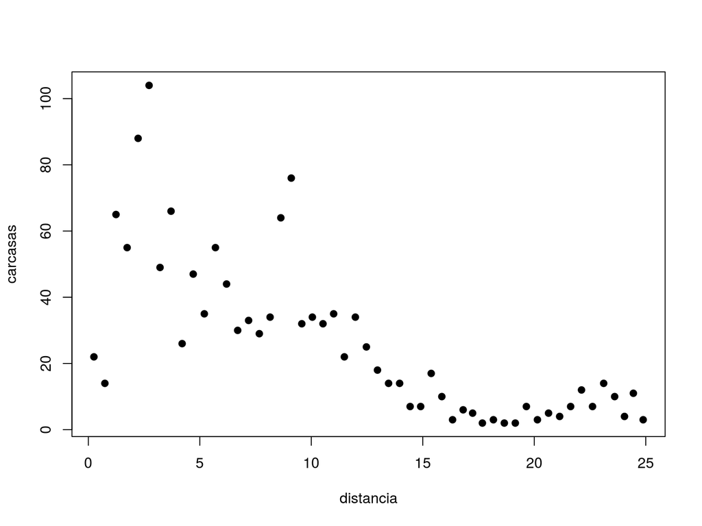

```r
dat <- read.table("RoadKills.txt", header = TRUE)
fit <- lm(TOT.N ~ D.PARK, data=dat)
summary(fit)
```

```
##
## Call:
## lm(formula = TOT.N ~ D.PARK, data = dat)
##
## Residuals:
##     Min      1Q  Median      3Q     Max
## -41.470  -9.316  -1.511   6.269  53.441
##
## Coefficients:
##             Estimate Std. Error t value Pr(>|t|)
## (Intercept)  57.3049     4.5479  12.600  < 2e-16 ***
## D.PARK       -2.4763     0.3113  -7.955 1.95e-10 ***
## ---
## Signif. codes:  0 '***' 0.001 '**' 0.01 '*' 0.05 '.' 0.1 ' ' 1
##
## Residual standard error: 16.29 on 50 degrees of freedom
## Multiple R-squared:  0.5586, Adjusted R-squared:  0.5498
## F-statistic: 63.28 on 1 and 50 DF,  p-value: 1.952e-10
```

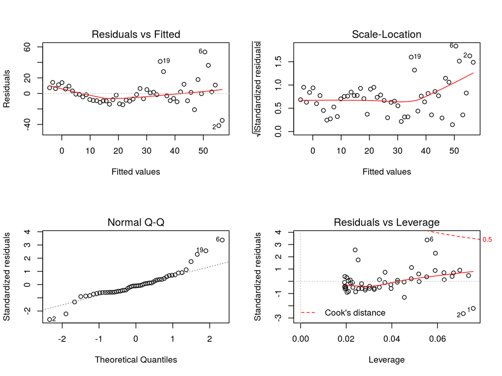

```r
dat <- read.table("RoadKills.txt", header = TRUE)
fit <- glm(TOT.N ~ D.PARK, data = dat, family = poisson)
summary(fit)
```

```
##
## Call:
## glm(formula = TOT.N ~ D.PARK, family = poisson, data = dat)
##
## Deviance Residuals:
##     Min       1Q   Median       3Q      Max
## -8.1100  -1.6950  -0.4708   1.4206   7.3337
##
## Coefficients:
##              Estimate Std. Error z value Pr(>|z|)
## (Intercept)  4.316485   0.043220   99.87   <2e-16 ***
## D.PARK      -0.105851   0.004387  -24.13   <2e-16 ***
## ---
## Signif. codes:  0 '***' 0.001 '**' 0.01 '*' 0.05 '.' 0.1 ' ' 1
##
## (Dispersion parameter for poisson family taken to be 1)
##
##     Null deviance: 1071.4  on 51  degrees of freedom
## Residual deviance:  390.9  on 50  degrees of freedom
## AIC: 634.29
##
## Number of Fisher Scoring iterations: 4
```

# ¿Es significativa la devianza residual?

Esto indicaría un mal ajuste del modelo, si bien es un test vago.

```r
pchisq(390.9, 50, lower.tail=F)
```

```
## [1] 2.321894e-54
```

```r
dat <- read.table("RoadKills.txt", header = TRUE)
fit <- glm(TOT.N ~ D.PARK, data = dat, family = poisson)
anova(fit, test = "Chisq")
```

```
## Analysis of Deviance Table
##
## Model: poisson, link: log
##
## Response: TOT.N
##
## Terms added sequentially (first to last)
##
##
##        Df Deviance Resid. Df Resid. Dev  Pr(>Chi)
## NULL                      51     1071.4
## D.PARK  1   680.55        50      390.9 < 2.2e-16 ***
## ---
## Signif. codes:  0 '***' 0.001 '**' 0.01 '*' 0.05 '.' 0.1 ' ' 1
```

```r
dat <- read.table("RoadKills.txt", header = TRUE)
fit0 <- glm(TOT.N ~ 1, data = dat, family = poisson)
fit1 <- glm(TOT.N ~ D.PARK, data = dat, family = poisson)
anova(fit0, fit1, test = "Chisq")
```

```
## Analysis of Deviance Table
##
## Model 1: TOT.N ~ 1
## Model 2: TOT.N ~ D.PARK
##   Resid. Df Resid. Dev Df Deviance  Pr(>Chi)
## 1        51     1071.4
## 2        50      390.9  1   680.55 < 2.2e-16 ***
## ---
## Signif. codes:  0 '***' 0.001 '**' 0.01 '*' 0.05 '.' 0.1 ' ' 1
```

La diferencia de devianzas se distribuye como $\chi^2$ con sus grados de libertad igual a la diferencia de grados de libertad entre los modelos.

### Interpretación de parámetros

```r
dat <- read.table("RoadKills.txt", header = TRUE)
fit <- glm(TOT.N ~ D.PARK, data = dat, family = poisson)
fit$coefficients
```

```
## (Intercept)      D.PARK
##   4.3164850  -0.1058506
```

```r
exp(fit$coefficients)
```

```
## (Intercept)      D.PARK
##   74.924803    0.899559
```

```r
1/exp(fit$coefficients)
```

```
## (Intercept)      D.PARK
##  0.01334672  1.11165580
```

El número de muertos disminuye un 11.17% por cada kilómetro de distancia.

### Interpretación de parámetros

- Si b es cercano a 0, exp(b) es cercano a 1. El efecto es pequeño.
- Si b es 0.13976, exp(b) es 1.15. Por cada aumento de una unidad en la variable X, la variable Y se incrementa un 15%.
- Si b es -0.2231, exp(b) es 0.80, 1/exp(b) es 1.25. Por cada disminución de una unidad en la variable X, la variable Y disminuye un 25%.

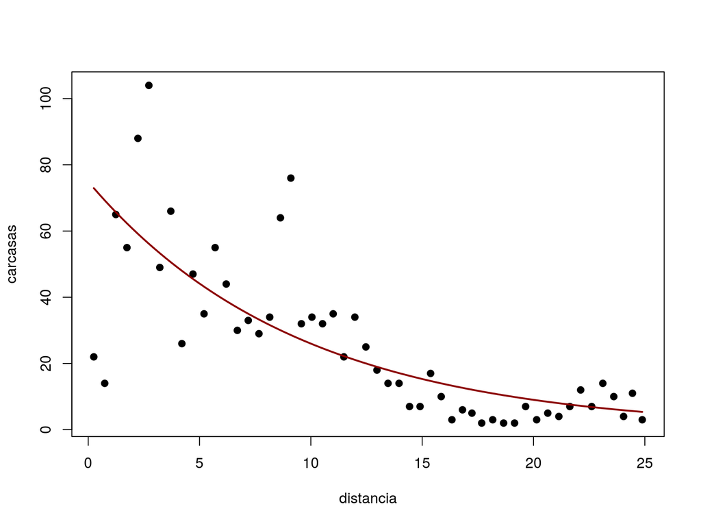

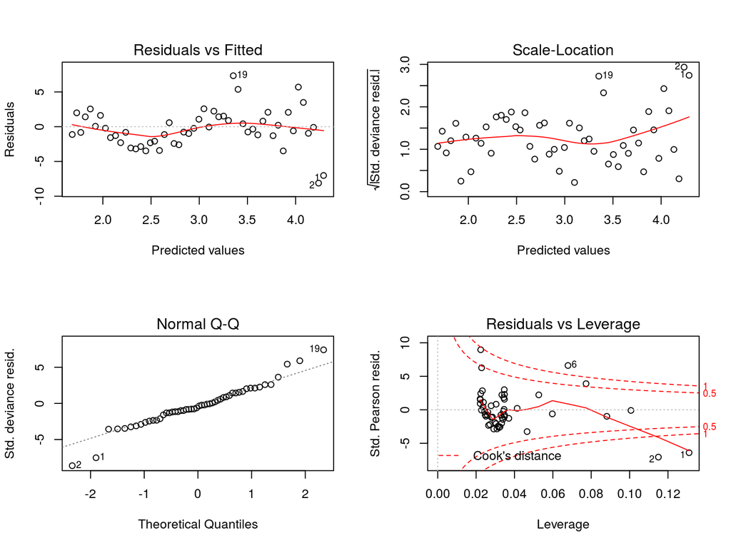

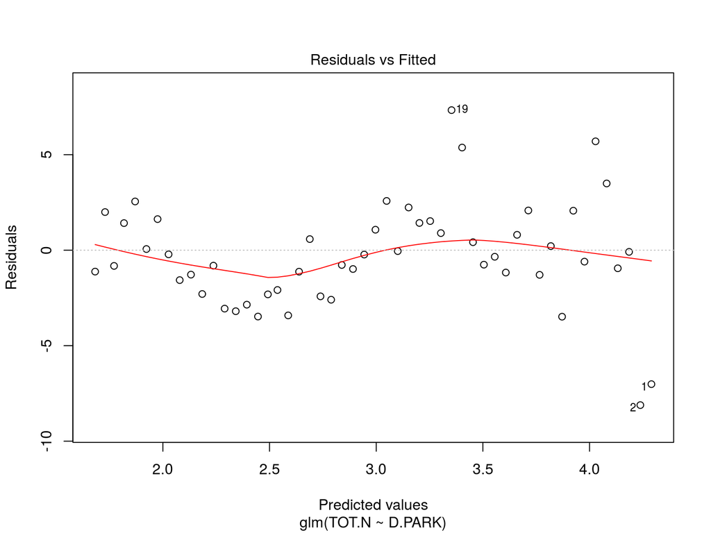

Ver el patrón de serpenteo. Violación de supuestos?

# Sobredispersión

### Sobredispersión

- La sobredispersión es provocada por variación al azar **NO EXPLICADA** en la variable respuesta.
- Habitualmente se observa una importante devianza residual, que permanece incluso si se incorporan variables al modelo.
- Esta variabilidad provoca que la relación media-varianza esperada para la familia no se cumpla.
- Debe distinguirse de la sobredispersión aparente , debida a variables o interacciones faltantes, efectos no lineales no considerados, outliers en la variable respuesta o errores en la elección del enlace.

Uno de los supuestos de un MLG es que la variable dependiente se ajusta a una de las funciones de la familia exponencial. Cada una de estas familias está caracterizada por una relación media-varianza específica.

| Distribución | Posición | Dispersión |
| --- | --- | --- |
| **Poisson** | $E(Y) = \mu$ | $var(Y) = \mu$ |
| **Binomial** | $E(Y) = N\pi$ | $var(Y) = N\pi(1-\pi)$ |

Sin embargo, a veces la variabilidad observada es mayor en una proporción $\phi$ respecto a lo esperado. Si $\phi > 1$ entonces existe sobredispersión

| Distribución | Posición | Dispersión |
| --- | --- | --- |
| **Poisson** | $E(Y) = \mu$ | $var(Y) = \phi\mu$ |
| **Binomial** | $E(Y) = N\pi$ | $var(Y) = \phi N\pi(1-\pi)$ |

> La sobredispersión provoca que los errores estándar de los parámetros sean la raíz cuadrada de $\phi$ veces más chicos que lo que deberían (y aumenta por tanto el error de tipo I)

### JAMÁS pueden presentar sobredispersión:

1- Datos binarios (Binomiales no agregados: 0 y 1).  
2- Cuando el modelo en consideración es el saturado (como los modelos loglineales para tablas de contingencia).

> Si nuestro modelo presenta un buen ajuste y aún así permanece mucha devianza residual no explicada debemos estimar $\phi$ para probar si existe sobredispersión.
- El parámetro $\phi$ es igual a la suma de los residuos Pearson sobre sus grados de libertad (o a la devianza residual sobre los grados de libertad). Para evitar hacer la cuenta podemos ajustar un modelo de quasiverosimilitud.
- En caso de ser significativa la sobre dispersión, nuestro modelo final será el de quasiverosimilitud.

> No hay acuerdo en cuál es la magnitud de sobredispersión tolerable. Podemos usar una aproximación práctica (examinar si los valores P cambian significativamente), o usar el límite arbitrario de $\phi$ > 2.

```
##
## Call:
## glm(formula = TOT.N ~ D.PARK, family = poisson, data = dat)
##
## Deviance Residuals:
##     Min       1Q   Median       3Q      Max
## -8.1100  -1.6950  -0.4708   1.4206   7.3337
##
## Coefficients:
##              Estimate Std. Error z value Pr(>|z|)
## (Intercept)  4.316485   0.043220   99.87   <2e-16 ***
## D.PARK      -0.105851   0.004387  -24.13   <2e-16 ***
## ---
## Signif. codes:  0 '***' 0.001 '**' 0.01 '*' 0.05 '.' 0.1 ' ' 1
##
## (Dispersion parameter for poisson family taken to be 1)
##
##     Null deviance: 1071.4  on 51  degrees of freedom
## Residual deviance:  390.9  on 50  degrees of freedom
## AIC: 634.29
##
## Number of Fisher Scoring iterations: 4
```

```
## Analysis of Deviance Table
##
## Model: poisson, link: log
##
## Response: TOT.N
##
## Terms added sequentially (first to last)
##
##
##        Df Deviance Resid. Df Resid. Dev      F    Pr(>F)
## NULL                      51     1071.4
## D.PARK  1   680.55        50      390.9 680.55 < 2.2e-16 ***
## ---
## Signif. codes:  0 '***' 0.001 '**' 0.01 '*' 0.05 '.' 0.1 ' ' 1
```

### Modelos de cuasiverosimilitud.

> No existen la “familia quasipoisson” o “quasibinomial”, sino que especificamos una relación media-varianza y ajustamos el modelo mediante cuasiverosimilitud.
- Ventaja: Controlan la sobredispersión, por lo que disminuyen el error del valor P, los valores estimados de los parámetros (y por lo tanto la interpretación biológica) no cambian.
- Desventaja: Dificultan la selección e modelos, se utiliza QAIC en vez de AIC.

# Modelos Binomiales Negativos.

| Distribución | Posición | Dispersión |
| --- | --- | --- |
| **Poisson** | $E(Y) = \mu$ | $var(Y) = \mu$ |
| **Binomial Negativa** | $E(Y) = N\pi$ | $var(Y) = \mu + \theta\mu^2$ |

> El parámetro $\theta$ regula la sobredispersión.

```r
library(MASS)
dat <- read.table("RoadKills.txt", header = TRUE)
nbfit <- glm.nb(TOT.N ~ D.PARK, data=dat)
summary(nbfit)
```

```
##
## Call:
## glm.nb(formula = TOT.N ~ D.PARK, data = dat, init.theta = 3.681040094,
##     link = log)
##
## Deviance Residuals:
##     Min       1Q   Median       3Q      Max
## -2.4160  -0.8289  -0.2116   0.4800   2.1346
##
## Coefficients:
##             Estimate Std. Error z value Pr(>|z|)
## (Intercept)  4.41072    0.15476   28.50   <2e-16 ***
## D.PARK      -0.11612    0.01137  -10.21   <2e-16 ***
## ---
## Signif. codes:  0 '***' 0.001 '**' 0.01 '*' 0.05 '.' 0.1 ' ' 1
##
## (Dispersion parameter for Negative Binomial(3.681) family taken to be 1)
##
##     Null deviance: 155.445  on 51  degrees of freedom
## Residual deviance:  54.742  on 50  degrees of freedom
## AIC: 393.09
##
## Number of Fisher Scoring iterations: 1
##
##
##               Theta:  3.681
##           Std. Err.:  0.891
##
##  2 x log-likelihood:  -387.093
```

```r
library(MASS)
dat <- read.table("RoadKills.txt", header = TRUE)
nbfit <- glm.nb(TOT.N ~ D.PARK, data=dat)
anova(nbfit, test = "Chisq")
```

```
## Analysis of Deviance Table
##
## Model: Negative Binomial(3.681), link: log
##
## Response: TOT.N
##
## Terms added sequentially (first to last)
##
##
##        Df Deviance Resid. Df Resid. Dev  Pr(>Chi)
## NULL                      51    155.445
## D.PARK  1    100.7        50     54.742 < 2.2e-16 ***
## ---
## Signif. codes:  0 '***' 0.001 '**' 0.01 '*' 0.05 '.' 0.1 ' ' 1
```

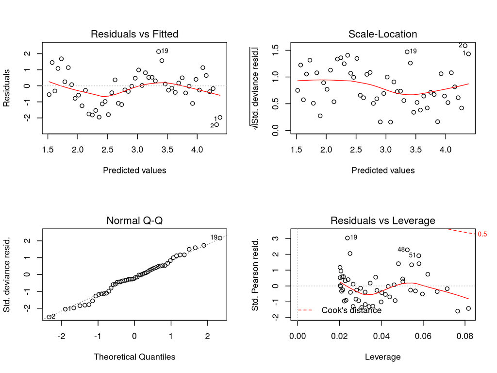

- Los modelos con la familia binomial negativa pueden estar sobredispersos (examinar la devianza residual). Pero no existen métodos de cuasi-verosimilitud para ellos.
- La familia binomial negativa permite calcular el AIC, lo que facilita la elección de modelos.
- Los modelos binomial negativos están anidados dentro de un modelo poisson, ya que solamente difieren en un parámetro ($\theta$). Puede testearse su adecuación con una cociente de verosimilitudes.

```r
library(MASS)
dat <- read.table("RoadKills.txt", header = TRUE)
nbfit <- glm.nb(TOT.N ~ D.PARK, data = dat)
pofit <- glm(TOT.N ~ D.PARK, data = dat, family = poisson)
L.NB = logLik(nbfit); L.NB
```

```
## 'log Lik.' -193.5465 (df=3)
```

```r
L.Po = logLik(pofit); L.Po
```

```
## 'log Lik.' -315.1434 (df=2)
```

```r
d <- 2 * (L.NB - L.Po)
attributes(d) <- NULL # para borrar resultados innecesarios
d
```

```
## [1] 243.1939
```

```r
pchisq(d, df = 1, lower.tail = FALSE)/2
```

```
## [1] 3.956301e-55
```